# Fisheries induced shifts in sea snake assemblages along the Konkan coast of India

Supplementary materials B: Analysis and Figures

Rao, C., Dsouza, S., Gupta, T., Manoharakrishnan, M. and Lobo, A.S.

```r
options(max.print="75")
knitr::opts_chunk$set(echo = T, error = T, warning = F, message = F, tidy = T, cache = T,
                      dpi = 300, fig.align = "center", eval = T)

#Required libraries
suppressPackageStartupMessages(library(plyr))
suppressPackageStartupMessages(library(tidyverse))
suppressPackageStartupMessages(library(lubridate))
suppressPackageStartupMessages(library(RColorBrewer))

#Importing sea snake bycatch data

snakes = read.csv("./Data/Rao et al_data_sea snake bycatch.csv")


# Fixing tow duration for 2018 - 2019

snakes <- snakes%>%
  mutate(Month = factor(months(dmy(Date), abbreviate = T), levels = month.abb))%>%
  group_by(Year, Gear.Type)%>%
  mutate(n.hauls = ifelse(is.na(No..of.Hauls), #filling in missing data
                         mean(No..of.Hauls, na.rm = T), No..of.Hauls),
         haul.time = ifelse(is.na(Average.Haul.Duration..Hours.),
                         mean(Average.Haul.Duration..Hours., na.rm = T),
                         Average.Haul.Duration..Hours.))%>%
  ungroup()%>%
  mutate(Tow.duration.hours =
           ifelse(is.na(Tow.duration.hours), # only for TD not recorded
                    ifelse(Gear.Type == "GillNet", #for gillnets
                            (haul.time+1.75), #soak time correction
                           ifelse(Gear.Type == "Trawler", #for trawlers
                                  n.hauls*haul.time, # total tow duration
                                  Tow.duration.hours) #return unchanged
                           ), #return unchanged
                    Tow.duration.hours)# return same for TD recorded
         )

#setting ggplot theme

theme_set(theme_bw()+
            theme(legend.position = "top",
                  text = element_text(size = 15)
                  )
          )

# function calculating mcfadden's pseudo r2 for glms

mcfadden <- function(x){
  r2 <- 1 - (x$deviance/x$null.deviance)
}

# function for calculating effect size for Z - test

proptest.r <- function(x, y){
  r <- x$statistic/sum(y$N)
}
```

# 1 Composition of sea snakes in bycatch

## 1.1 Sampling effort

We calculated the number of trips sampled and fishing effort per trip (Tow duration in hours) to determine sampling effort per month of each year of sampling.

```r
#Number of boats sampled accross years

snakes%>%
  group_by(Year, Month)%>%
  distinct(Date, Boat.Name, .keep_all = T)%>%
  #filter(!Boat.Name == "")%>%
  count(name = "n.trips")%>%
  spread(Month, n.trips)
```

| Year | Jan | Feb | Mar | Apr | May | Oct | Nov | Dec |
| --- | --- | --- | --- | --- | --- | --- | --- | --- |
| 2016 | 2 | 8 | 8 | 3 | 6 | NA | 4 | 10 |
| 2017 | 12 | 19 | 15 | NA | NA | NA | 1 | 6 |
| 2018 | 91 | 56 | 59 | 15 | 22 | 18 | 41 | 44 |

```r
# Fishing effort accross years

snakes%>%
  filter(Gear.Type == "GillNet" | Gear.Type == "Trawler")%>%
  group_by(Gear.Type, Year, Month)%>%
  distinct(Date, Boat.Name, .keep_all = T)%>%
  summarise(sampling.effort = round(sum(Tow.duration.hours, na.rm = T), 2))%>%
  spread(Month, sampling.effort, fill = c(0))
```

| Gear.Type | Year | Jan | Feb | Mar | Apr | May | Oct | Nov | Dec |
| --- | --- | --- | --- | --- | --- | --- | --- | --- | --- |
| GillNet | 2016 | 9.00 | 29.00 | 24.00 | 7.00 | 21.00 | 0.00 | 10.00 | 36.50 |
| GillNet | 2017 | 3.00 | 27.00 | 9.00 | 0.00 | 0.00 | 0.00 | 0.00 | 0.00 |
| GillNet | 2018 | 206.91 | 112.87 | 128.63 | 25.88 | 51.63 | 43.51 | 62.26 | 109.38 |
| Trawler | 2016 | 0.00 | 8.00 | 9.00 | 9.00 | 8.00 | 0.00 | 0.00 | 0.00 |
| Trawler | 2017 | 84.00 | 105.00 | 52.50 | 0.00 | 0.00 | 0.00 | 0.00 | 15.00 |
| Trawler | 2018 | 49.00 | 50.91 | 30.50 | 11.75 | 0.00 | 0.00 | 11.00 | 5.50 |

```r
snakes%>%
  filter(Gear.Type == "Trawler" | Gear.Type == "GillNet")%>%
  group_by(Gear.Type)%>%
  distinct(Date, Boat.Name, .keep_all = T)%>%
  summarise(n.trips = n(),
            sampling.effort = round(sum(Tow.duration.hours, na.rm = T), 2),
            n.boats = length(unique(Boat.Name)))
```

| Gear.Type | n.trips | sampling.effort | n.boats |
| --- | --- | --- | --- |
| GillNet | 329 | 916.57 | 136 |
| Trawler | 65 | 449.16 | 6 |

Sampling was not conducted trip wise for 2016 and most of 2017. Hence, effort data is unavailable.

## 1.2 Assemblage composition

We computed the abundance of each species of snake encountered over the whole sampling duration and across years

```r
snakes%>%
  group_by(Species, Year)%>%
  count(name = "Abundance")%>%
  spread(Year, Abundance)
```

| Species | 2016 | 2017 | 2018 |
| --- | --- | --- | --- |
| Acrochordus granulatus | NA | 1 | NA |
| Hydrophis curtus | 75 | 38 | 123 |
| Hydrophis cyanocinctus | NA | NA | 3 |
| Hydrophis schistosus | 178 | 215 | 521 |
| Hydrophis viperinus | NA | 1 | 1 |

## 1.3 Varition in catch per unity effort (CPUE) of sea snakes across years in each gear

We considered only the two dominant species for in depth analysis. Catch Per Unit Effort (CPUE) for each species in each sampled trip was calculated as ‘Abundance of snakes encountered over Total Tow Duration or Soak Time’. We tested the effect of Tow duration on CPUE of each species using a log – linear regression. We compared the catch rates (CPUE) of each species across and within gears using log – linear regression.

```r
CPUE.grsp <- snakes%>%
  filter(Gear.Type == "GillNet" | Gear.Type == "Trawler")%>%
  filter(Species == "Hydrophis curtus" |
           Species == "Hydrophis schistosus",
         Boat.Name != "")%>% # keeping dominant species
  droplevels()%>%
  group_by(Year, Gear.Type, Date, Boat.Name, Species)%>%
  summarise(Abn = n(), # abundance of sea snakes per trip
            fe = mean(Tow.duration.hours, na.rm = T))%>% # fishing effort, mean for 2016 - 17
  complete(nesting(Year, Gear.Type, Date, Boat.Name, fe),
           Species, fill = list(Abn = 0))%>% # completing species x trip combinations
  mutate(cpue = Abn/fe)%>%
  group_by(Boat.Name)%>%
  mutate(n = n())%>%
  ungroup()

CPUE.grsp%>%
  group_by(Gear.Type, Species)%>%
  summarise(Mean.CPUE = mean(cpue, na.rm = T))%>%
  spread(Species, Mean.CPUE)
```

| Gear.Type | Hydrophis curtus | Hydrophis schistosus |
| --- | --- | --- |
| GillNet | 0.4243868 | 0.4647042 |
| Trawler | 1.1981818 | 1.7018479 |

```r
CPUE.grsp%>%
  group_by(Gear.Type,Species)%>%
  nest()%>%
  mutate(shapiro = map(data, ~shapiro.test(.$cpue)),
         sumry = map(shapiro, broom::tidy))%>%
  select(sumry)%>%
  unnest()
```

| Gear.Type | Species | statistic | p.value | method |
| --- | --- | --- | --- | --- |
| GillNet | Hydrophis schistosus | 0.4785970 | 0.0000000 | Shapiro-Wilk normality test |
| GillNet | Hydrophis curtus | 0.7492041 | 0.0000001 | Shapiro-Wilk normality test |
| Trawler | Hydrophis curtus | 0.6313492 | 0.0001311 | Shapiro-Wilk normality test |
| Trawler | Hydrophis schistosus | 0.7890101 | 0.0003384 | Shapiro-Wilk normality test |

```r
# testing difference in CPUE between trawlers and gillnets

library(lme4)

CPUE.grsp%>%
  group_by(Species)%>%
  nest()%>%
  mutate(mod = map(data, ~lmer(cpue ~ Gear.Type + (1|Boat.Name), data = .)),
         sumry = map(mod, broom.mixed::tidy))%>%
  select(sumry)%>%
  unnest()
```

| Species | effect | group | term | estimate | std.error | statistic |
| --- | --- | --- | --- | --- | --- | --- |
| Hydrophis schistosus | fixed | NA | (Intercept) | 0.4640419 | 0.0435137 | 10.664273 |
| Hydrophis schistosus | fixed | NA | Gear.TypeTrawler | 1.2257846 | 0.1431319 | 8.564023 |
| Hydrophis schistosus | ran_pars | Boat.Name | sd__(Intercept) | 0.0555275 | NA | NA |
| Hydrophis schistosus | ran_pars | Residual | sd__Observation | 0.6191548 | NA | NA |
| Hydrophis curtus | fixed | NA | (Intercept) | 0.4206151 | 0.1105983 | 3.803089 |
| Hydrophis curtus | fixed | NA | Gear.TypeTrawler | 1.0609298 | 0.3247348 | 3.267065 |
| Hydrophis curtus | ran_pars | Boat.Name | sd__(Intercept) | 0.4440595 | NA | NA |
| Hydrophis curtus | ran_pars | Residual | sd__Observation | 0.5613696 | NA | NA |

```r
CPUE.grsp%>%
  group_by(Species)%>%
  nest()%>%
  mutate(mod = map(data, ~lmer(cpue ~ Gear.Type + (1|Boat.Name), data = .)),
         anva = map(mod, car::Anova),
         sumry = map(anva, broom::tidy))%>%
  select(sumry)%>%
  unnest()
```

| Species | term | statistic | df | p.value |
| --- | --- | --- | --- | --- |
| Hydrophis schistosus | Gear.Type | 73.34249 | 1 | 0.0000000 |
| Hydrophis curtus | Gear.Type | 10.67372 | 1 | 0.0010867 |

```r
# testing difference in CPUE between Species

CPUE.grsp%>%
  group_by(Gear.Type)%>%
  nest()%>%
  mutate(mod = map(data, ~lmer(cpue ~ Species + (1|Boat.Name), data = .)),
         sumry = map(mod, broom::tidy))%>%
  select(sumry)%>%
  unnest()
```

| Gear.Type | effect | group | term | estimate | std.error | statistic |
| --- | --- | --- | --- | --- | --- | --- |
| GillNet | fixed | NA | (Intercept) | 0.4244221 | 0.0437981 | 9.6904140 |
| GillNet | fixed | NA | SpeciesHydrophis schistosus | 0.0402291 | 0.0485110 | 0.8292770 |
| GillNet | ran_pars | Boat.Name | sd__(Intercept) | 0.0082453 | NA | NA |
| GillNet | ran_pars | Residual | sd__Observation | 0.3000941 | NA | NA |
| Trawler | fixed | NA | (Intercept) | 1.6265715 | 0.7494314 | 2.1704076 |
| Trawler | fixed | NA | SpeciesHydrophis schistosus | -0.3410434 | 0.6845323 | -0.4982138 |
| Trawler | ran_pars | Boat.Name | sd__(Intercept) | 1.1674491 | NA | NA |
| Trawler | ran_pars | Residual | sd__Observation | 1.5111595 | NA | NA |

```r
CPUE.grsp%>%
  group_by(Gear.Type)%>%
  nest()%>%
  mutate(mod = map(data, ~lmer(cpue ~ Species + (1|Boat.Name), data = .)),
         anva = map(mod, car::Anova),
         sumry = map(anva, broom::tidy))%>%
  select(sumry)%>%
  unnest()
```

| Gear.Type | term | statistic | df | p.value |
| --- | --- | --- | --- | --- |
| GillNet | Species | 0.6877004 | 1 | 0.4069477 |
| Trawler | Species | 0.2482170 | 1 | 0.6183334 |

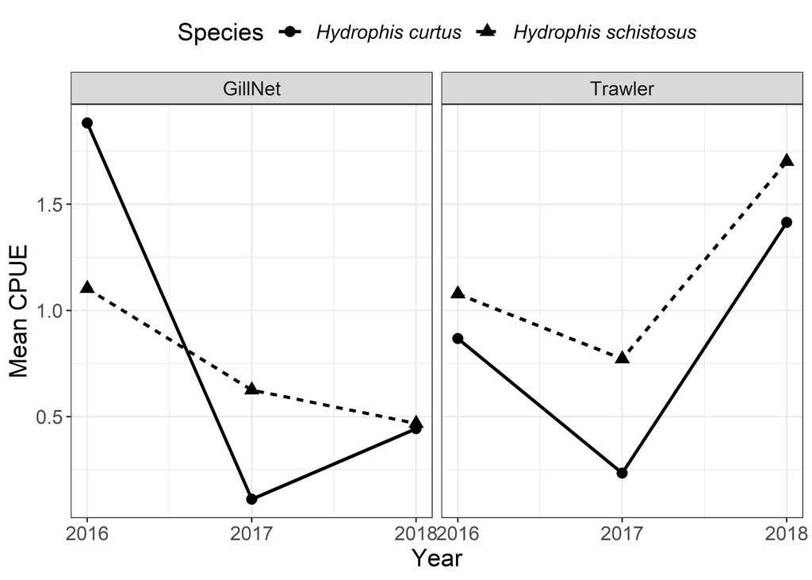

```r
#Plotting

snakes%>%
  filter(Gear.Type == "GillNet" | Gear.Type == "Trawler")%>%
  filter(Species == "Hydrophis curtus" |
           Species == "Hydrophis schistosus")%>% # keeping dominant species
  droplevels()%>%
  group_by(Year, Gear.Type, Date, Boat.Name, Species)%>%
  summarise(Abn = n(), # abundance of sea snakes per trip
            fe = mean(Tow.duration.hours, na.rm = T))%>% # fishing effort, mean for 2016 - 17
  complete(nesting(Year, Gear.Type, Date, Boat.Name, fe),
           Species, fill = list(Abn = 0))%>% # completing species x trip combinations
  group_by(Year, Gear.Type, Species)%>%
  summarise(CPUE = mean(Abn/fe, na.rm = T), # Mean CPUE per trip
            sd = sd(Abn/fe, na.rm = T))%>%
  ggplot(aes(Year, CPUE, shape = Species, group = Species))+
  geom_point(size = 3)+
  geom_line(aes(linetype = Species), size = 1)+
  scale_x_continuous(breaks = seq(2016, 2018, 1))+
  labs(y = "Mean CPUE")+
  facet_wrap(~Gear.Type)+
  theme(legend.text = element_text(face = "italic"))
```

```r
ggsave("./Figures/figure 1.tiff", device = "tiff", last_plot(), dpi = "print",
       height = 4.5, width = 8)
```

## 1.4 Seasonal variation in CPUE

We tested for seasonality in bycatch trends for each species in each gear using log – linear regressions with months as predictor variables.

```r
# testing seasonality in CPUE by gear

CPUE.month <- snakes%>%
  filter(Gear.Type == "GillNet" | Gear.Type == "Trawler")%>%
  filter(Species == "Hydrophis curtus" |
           Species == "Hydrophis schistosus")%>% # keeping dominant species
  droplevels()%>%
  group_by(Year, Month, Gear.Type, Date, Boat.Name, Species)%>%
  summarise(Abn = n(), # abundance of sea snakes per trip
            fe = mean(Tow.duration.hours, na.rm = T))%>% # fishing effort, mean for 2016 - 17
  complete(nesting(Year, Month, Gear.Type, Date, Boat.Name, fe),
           Species, fill = list(Abn = 0))%>% # completing species x trip combinations
  mutate(CPUE = Abn/fe) # Mean CPUE per trip


CPUE.month%>%
  ungroup()%>%
  group_by(Gear.Type, Species)%>%
  nest()%>%
  mutate(mod = map(data, ~lmer(CPUE ~ Month + (1|Boat.Name), data = .)),
         sumry = map(mod, broom::tidy),
         tst = map(mod, car::Anova))%>%
  select(sumry)%>%
  unnest()%>%
  select(term, estimate)%>%
  spread(term, estimate, drop = T)
```

| Gear.Type | Species | (Intercept) | MonthApr | MonthDec | MonthFeb | MonthMar | MonthMay | MonthNov | MonthOct | sd__(Intercept) | sd__Observation |
| --- | --- | --- | --- | --- | --- | --- | --- | --- | --- | --- | --- |
| GillNet | Hydrophis curtus | 0.3474585 | 1.2261151 | 0.1051078 | 0.0721653 | 1.6615975 | NA | 0.0344719 | 0.0343597 | 0.0000000 | 0.8967478 |
| GillNet | Hydrophis schistosus | 0.4313831 | 0.0670926 | 0.0095525 | 0.5993502 | 0.0363549 | 0.0028650 | -0.0718391 | -0.0360249 | 0.0949908 | 0.5935458 |
| Trawler | Hydrophis curtus | 0.3366162 | -0.1013220 | 0.4050505 | -0.0995791 | -0.1143939 | NA | 3.8300505 | NA | 0.0000000 | 0.6425533 |
| Trawler | Hydrophis schistosus | 0.7202427 | 1.6230328 | 0.9464240 | 0.3707643 | 0.4578930 | 0.1702764 | 2.0797573 | NA | 0.4216842 | 1.1841602 |

```r
CPUE.month%>%
  ungroup()%>%
  group_by(Gear.Type, Species)%>%
  nest()%>%
  mutate(mod = map(data, ~lmer(CPUE ~ Month + (1|Boat.Name), data = .)),
         sumry = map(mod, broom::tidy),
         tst = map(mod, car::Anova))%>%
  select(tst)%>%
  unnest()
```

| Gear.Type | Species | Chisq | Df | Pr(>Chisq) |
| --- | --- | --- | --- | --- |
| GillNet | Hydrophis schistosus | 30.321943 | 7 | 0.0000829 |
| Trawler | Hydrophis schistosus | 8.054082 | 6 | 0.2341679 |
| GillNet | Hydrophis curtus | 23.811045 | 6 | 0.0005657 |
| Trawler | Hydrophis curtus | 67.330098 | 5 | 0.0000000 |

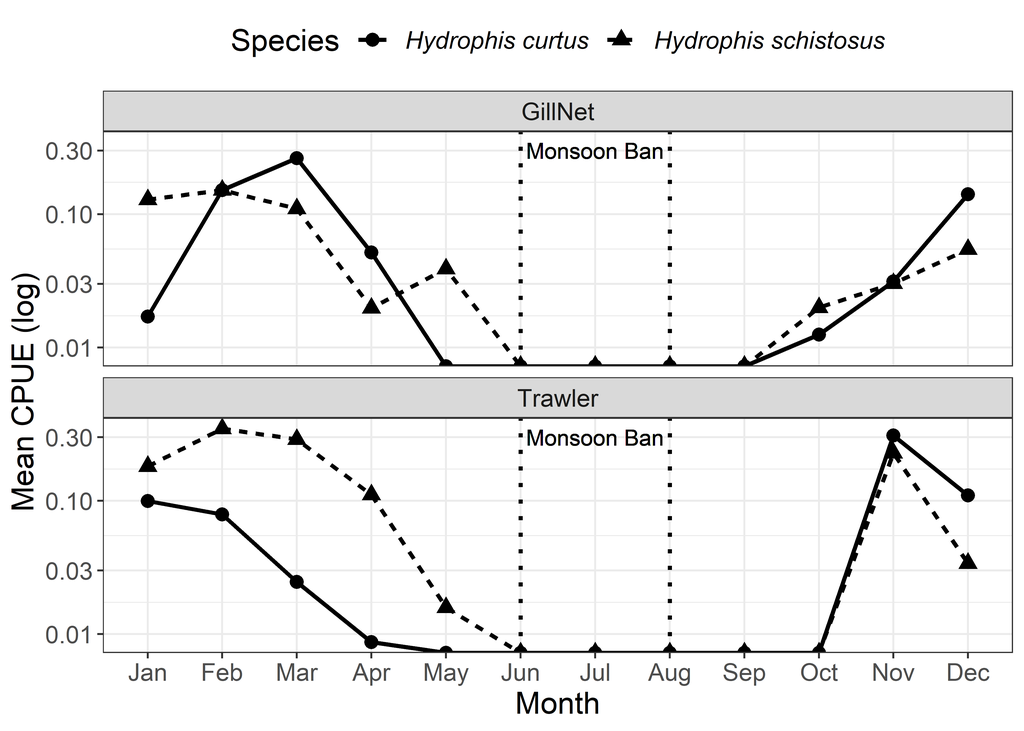

```r
#plotting

snakes%>%
  filter(Gear.Type == "GillNet" | Gear.Type == "Trawler")%>%
  filter(Species == "Hydrophis curtus" |
           Species == "Hydrophis schistosus")%>% # keeping dominant species
  droplevels()%>%
  mutate(Month = factor(Month, levels = month.abb))%>%
  group_by(Year, Month, Gear.Type, Date, Boat.Name, Species)%>%
  summarise(Abn = n(), # abundance of sea snakes per trip
            fe = mean(Tow.duration.hours, na.rm = T))%>% # fishing effort, mean for 2016 - 17
  complete(nesting(Year, Gear.Type, Date, Boat.Name, fe), Month,
           Species, fill = list(Abn = 0))%>% # completing species x trip combinations
  group_by(Month, Gear.Type, Species)%>%
  summarise(CPUE = mean(Abn/fe, na.rm = T), # Mean CPUE per trip
            sd = sd(Abn/fe, na.rm = T))%>%
  ggplot(aes(Month, CPUE, shape = Species,  group = Species))+
  geom_point(size = 3)+
  geom_line(aes(linetype = Species), size = 1)+
  scale_y_log10()+
  geom_vline(xintercept = "Jun", size = 1, linetype = "dotted")+
  geom_vline(xintercept = "Aug", size = 1, linetype = "dotted")+
  geom_text(aes(x = "Jul", y = 0.3, label = "Monsoon Ban"))+
  labs(y = "Mean CPUE (log)")+
  facet_wrap(~Gear.Type, ncol = 1)+
  theme(legend.text = element_text(face = "italic"))
```

```r
ggsave("./Figures/figure 2.tiff", device = "tiff", last_plot(), dpi = "print",
       height = 4.5, width = 8)
```

## 1.5 Length distribution in bycatch

We determined selectivity of gears with respect to SVL of individuals using a t – test for each species in each gear.

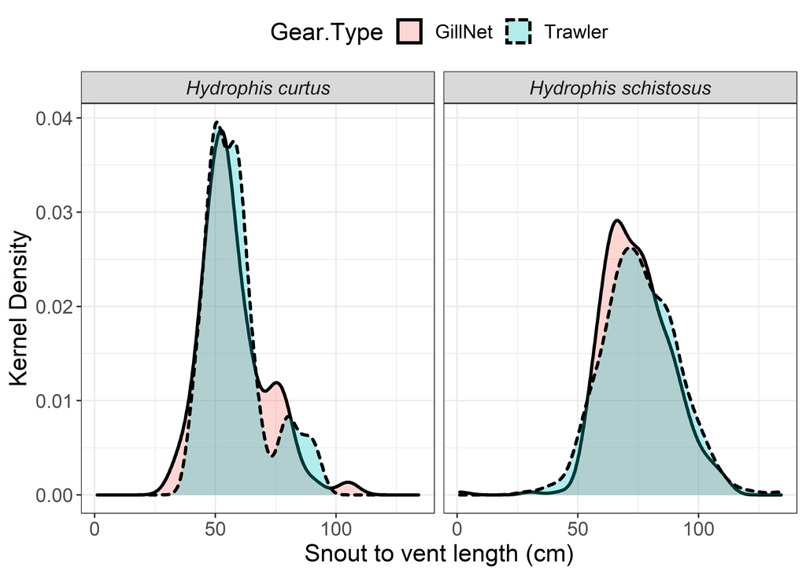

```r
#plotting

snakes%>%
  filter(Gear.Type == "GillNet" | Gear.Type == "Trawler")%>%
  filter(Species == "Hydrophis curtus" |
           Species == "Hydrophis schistosus")%>% # keeping dominant species
  ggplot(aes(Snout.to.Vent..cm., fill = Gear.Type))+
  geom_density(aes(linetype = Gear.Type),alpha = 0.3, size = 1)+
  labs(x = "Snout to vent length (cm)", y = "Kernel Density")+
  facet_wrap(~Species)+
  theme(strip.text = element_text(face = "italic"))
```

```r
# summary SVL

snakes%>%
  filter(Species == "Hydrophis curtus" | Species == "Hydrophis schistosus")%>%
  group_by(Species)%>%
  skimr::skim(Snout.to.Vent..cm.)%>%
  skimr::yank("numeric")
```

**Variable type: numeric**

| skim_variable | Species | n_missing | complete_rate | mean | sd | p0 | p25 | p50 | p75 | p100 | hist |
| --- | --- | --- | --- | --- | --- | --- | --- | --- | --- | --- | --- |
| Snout.to.Vent..cm. | Hydrophis curtus | 89 | 0.62 | 58.07 | 12.77 | 34.5 | 49.0 | 55.5 | 63.75 | 105.0 | ▃▇▃▂▁ |
| Snout.to.Vent..cm. | Hydrophis schistosus | 203 | 0.78 | 74.36 | 15.01 | 1.0 | 64.5 | 73.5 | 84.85 | 134.2 | ▁▁▇▃▁ |

```r
#Z - test for proportion

snakes%>%
  filter(Gear.Type == "GillNet" | Gear.Type == "Trawler")%>%
  filter(Species == "Hydrophis curtus" |
           Species == "Hydrophis schistosus")%>%
  filter(!is.na(Snout.to.Vent..cm.))%>%
  droplevels()%>%
  select(Gear.Type, Species, Snout.to.Vent..cm.)%>%
  group_by(Species)%>%
  nest()%>%
  mutate(t.test = map(data, ~t.test(Snout.to.Vent..cm. ~ Gear.Type, data = .)),
         sumry = map(t.test, broom::tidy),
         d = map(data, ~lsr::cohensD(Snout.to.Vent..cm. ~ Gear.Type, data = .)))%>%
  unnest(sumry, d)%>%
  select(estimate:p.value, d)
```

| Species | estimate | estimate1 | estimate2 | statistic | p.value | d |
| --- | --- | --- | --- | --- | --- | --- |
| Hydrophis curtus | -0.6316698 | 57.60896 | 58.24063 | -0.2802908 | 0.7797036 | 0.0489142 |
| Hydrophis schistosus | -1.6728765 | 74.32615 | 75.99903 | -1.4689341 | 0.1423528 | 0.1155450 |

## 1.6 Sex distibution in bycatch

We determined selectivity in terms of sex individuals using a two sample Z test for the proportion of females caught.

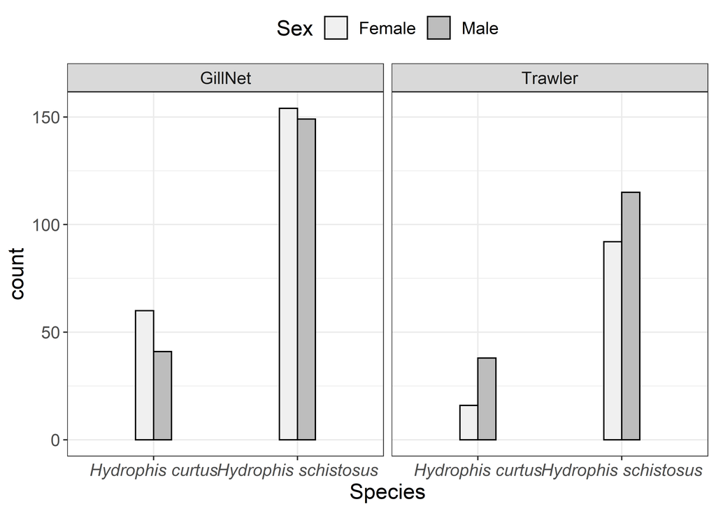

```r
#Plotting

snakes%>%
  filter(Sex == "Male" | Sex == "Female")%>% # sex recorded
  filter(Gear.Type == "GillNet" | Gear.Type == "Trawler")%>%
  filter(Species == "Hydrophis curtus" |
           Species == "Hydrophis schistosus")%>% # keeping dominant species
  ggplot(aes(Species, fill = Sex))+
  geom_bar(position = "dodge", col = "black", width = 0.25)+
  scale_fill_brewer(palette = "Greys")+
  facet_wrap(~Gear.Type)+
  theme(axis.text.x = element_text(face = "italic"))
```

```r
# Z - test for proportion

snakes%>%
  filter(Sex == "Male" | Sex == "Female")%>% # sex recorded
  filter(Gear.Type == "GillNet" | Gear.Type == "Trawler")%>%
  filter(Species == "Hydrophis curtus" |
           Species == "Hydrophis schistosus")%>%
  group_by(Gear.Type, Species, Sex)%>%
  count()%>%
  spread(Sex, n)%>%
  mutate(N = Male+Female)%>%
  group_by(Species)%>%
  nest()%>%
  mutate(prop = map(data, ~prop.test(.$Female, .$N)),
         sumry = map(prop, broom::tidy),
         r = map2(prop, data, ~proptest.r(x = .x, y = .y)))%>%
  unnest(sumry, r)%>%
  select(estimate1, estimate2, p.value, conf.low, conf.high, r)
```

| Species | estimate1 | estimate2 | p.value | conf.low | conf.high | r |
| --- | --- | --- | --- | --- | --- | --- |
| Hydrophis curtus | 0.5940594 | 0.2962963 | 0.0007665 | 0.1286188 | 0.4669074 | 0.0730372 |
| Hydrophis schistosus | 0.5082508 | 0.4444444 | 0.1848910 | -0.0282980 | 0.1559108 | 0.0034468 |

Significantly more male *H. curtus* caught in trawler than gillnets

# 2 Effect of effort on composition of sea snakes

We tested the effect of Tow duration on CPUE of each species using a log – linear regression.

```r
#Extracting CPUE data from bycatch database

CPUE = snakes%>%
  filter(Gear.Type == "GillNet" | Gear.Type == "Trawler")%>%
  filter(!Boat.Name == "")%>% # removing points with no effort
  filter(Species == "Hydrophis curtus" |
           Species == "Hydrophis schistosus")%>% # keeping dominant species
  droplevels()%>%
  group_by(Gear.Type, Date, Boat.Name, Species)%>%
  summarise(Abn = n(), # abundance of sea snakes per trip
            fe = mean(Tow.duration.hours, na.rm = T))%>% # fishing effort, mean for 2016 - 17
  complete(nesting(Gear.Type, Date, Boat.Name, fe),
           Species, fill = list(Abn = 0))%>%
  mutate(CPUE = Abn/fe,
         log.Abn = log(Abn),
         log.CPUE = log(CPUE),# log CPUE because CPUE is 0 inflated
          log.fe = log(fe))# fe is 0 inflated

#Sample size

CPUE%>%
  group_by(Gear.Type)%>%
  distinct(Date, Boat.Name)%>%
  count()
```

| Gear.Type | n |
| --- | --- |
| GillNet | 255 |
| Trawler | 27 |

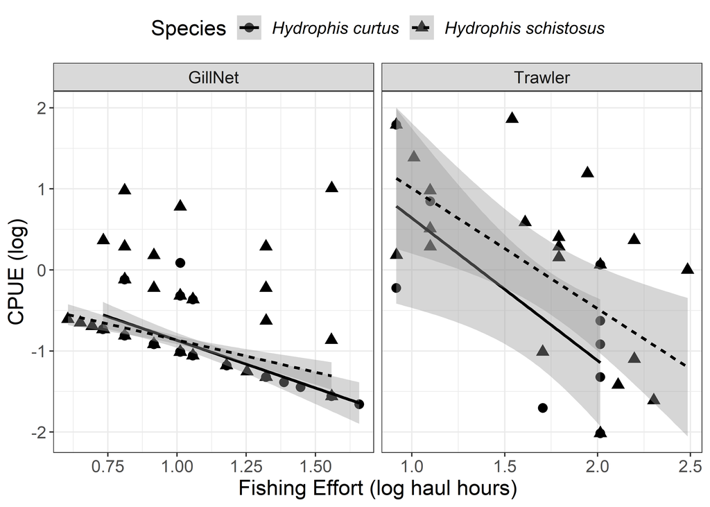

```r
#Plot

CPUE%>%
  ggplot(aes(log.fe, log.CPUE, shape = Species))+
  geom_jitter(size = 3)+
  geom_smooth(aes(linetype = Species), method = "lm", col = "black")+
  scale_color_brewer(palette = "Greys")+
  labs(y = "CPUE (log)", x = "Fishing Effort (log haul hours)")+
  facet_wrap(~ Gear.Type, scales = "free_x")+
  theme(legend.text = element_text(face = "italic"))
```

```r
# testing

CPUE%>%
  group_by(Gear.Type, Species)%>%
  nest()%>%
  mutate(mod = map(data, ~lmer(CPUE ~ fe + (1|Boat.Name), data = .)),
         sumry = map(mod, broom::tidy))%>%
  select(sumry)%>%
  unnest()
```

| Gear.Type | Species | effect | group | term | estimate | std.error | statistic |
| --- | --- | --- | --- | --- | --- | --- | --- |
| GillNet | Hydrophis curtus | fixed | NA | (Intercept) | 0.7987359 | 0.1100043 | 7.260953 |
| GillNet | Hydrophis curtus | fixed | NA | fe | -0.1260171 | 0.0359139 | -3.508871 |
| GillNet | Hydrophis curtus | ran_pars | Boat.Name | sd__(Intercept) | 0.0289787 | NA | NA |
| GillNet | Hydrophis curtus | ran_pars | Residual | sd__Observation | 0.1792341 | NA | NA |
| GillNet | Hydrophis schistosus | fixed | NA | (Intercept) | 0.6309144 | 0.1228337 | 5.136331 |
| GillNet | Hydrophis schistosus | fixed | NA | fe | -0.0596150 | 0.0433414 | -1.375476 |
| GillNet | Hydrophis schistosus | ran_pars | Boat.Name | sd__(Intercept) | 0.0000000 | NA | NA |
| GillNet | Hydrophis schistosus | ran_pars | Residual | sd__Observation | 0.3172430 | NA | NA |
| Trawler | Hydrophis curtus | fixed | NA | (Intercept) | 3.4636588 | 1.7235253 | 2.009636 |
| Trawler | Hydrophis curtus | fixed | NA | fe | -0.3850708 | 0.2993008 | -1.286568 |
| Trawler | Hydrophis curtus | ran_pars | Boat.Name | sd__(Intercept) | 1.3313764 | NA | NA |
| Trawler | Hydrophis curtus | ran_pars | Residual | sd__Observation | 1.1400297 | NA | NA |
| Trawler | Hydrophis schistosus | fixed | NA | (Intercept) | 3.9363791 | 0.9667292 | 4.071853 |
| Trawler | Hydrophis schistosus | fixed | NA | fe | -0.4062698 | 0.1380508 | -2.942899 |
| Trawler | Hydrophis schistosus | ran_pars | Boat.Name | sd__(Intercept) | 0.7191601 | NA | NA |
| Trawler | Hydrophis schistosus | ran_pars | Residual | sd__Observation | 1.4341989 | NA | NA |

```r
CPUE%>%
  group_by(Gear.Type, Species)%>%
  nest()%>%
  mutate(mod = map(data, ~lmer(CPUE ~ fe + (1|Boat.Name), data = .)),
         anva = map(mod, car::Anova),
         sumry = map(anva, broom::tidy))%>%
  select(sumry)%>%
  unnest()
```

| Gear.Type | Species | term | statistic | df | p.value |
| --- | --- | --- | --- | --- | --- |
| GillNet | Hydrophis curtus | fe | 12.312177 | 1 | 0.0004500 |
| GillNet | Hydrophis schistosus | fe | 1.891933 | 1 | 0.1689840 |
| Trawler | Hydrophis curtus | fe | 1.655257 | 1 | 0.1982450 |
| Trawler | Hydrophis schistosus | fe | 8.660658 | 1 | 0.0032515 |

# 3 Mortality rates of sea snakes in bycatch by gear

We compared risk of mortalities of each species across and within gears using binomial regression with conditions at encounter as the response variable.

```r
#Extracting mortality data from bycatch database

mortality <- snakes%>%
  filter(Gear.Type == "GillNet" | Gear.Type == "Trawler")%>%
  filter(Species == "Hydrophis curtus" |
           Species == "Hydrophis schistosus")%>% # keeping dominant species
  group_by(Gear.Type, Species)%>%
  summarise(n.alive = sum(Condition.at.encounter. == "Alive"),
            n.dead = sum(Condition.at.encounter. == "Dead"),
            mort.rate = (n.dead/(n.dead+n.alive))*100)

#table

knitr::kable(mortality)
```

| Gear.Type | Species | n.alive | n.dead | mort.rate |
| --- | --- | --- | --- | --- |
| GillNet | Hydrophis curtus | 97 | 34 | 25.954199 |
| GillNet | Hydrophis schistosus | 448 | 34 | 7.053942 |
| Trawler | Hydrophis curtus | 24 | 51 | 68.000000 |
| Trawler | Hydrophis schistosus | 236 | 110 | 31.791908 |

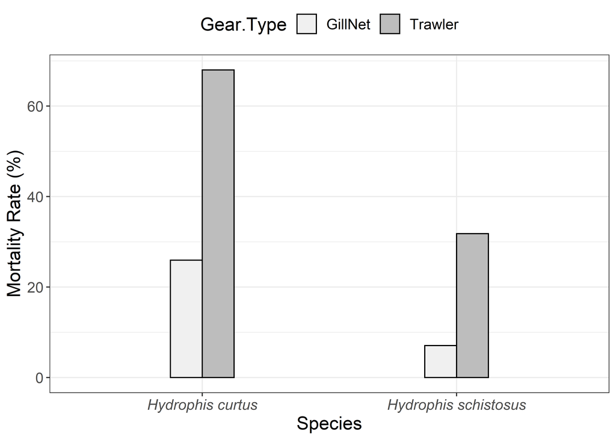

```r
#Plot

mortality%>%
  ggplot(aes(Species, mort.rate, fill = Gear.Type))+
  geom_col(position = "dodge", col = "black", width = 0.25)+
  scale_fill_brewer(palette = "Greys")+
  labs(x = "Species", y = "Mortality Rate (%)")+
  theme(axis.text.x = element_text(face = "italic"))
```

```r
ggsave("./Figures/figure 3.tiff", device = "tiff", last_plot(), dpi = "print",
       height = 4.5, width = 4.5)
```

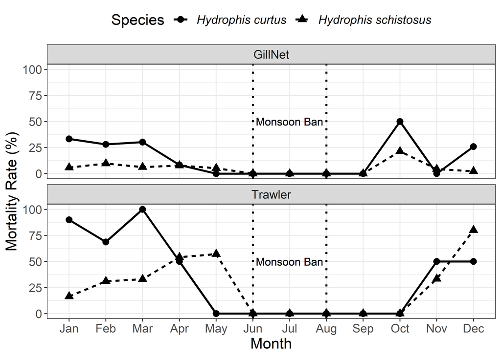

```r
# monthly mortalities

mortality.month <- snakes%>%
  filter(Gear.Type == "GillNet" | Gear.Type == "Trawler")%>%
  filter(Species == "Hydrophis curtus" |
           Species == "Hydrophis schistosus")%>% # keeping dominant species
  group_by(Month,Gear.Type, Species)%>%
  summarise(n.alive = sum(Condition.at.encounter. == "Alive"),
            n.dead = sum(Condition.at.encounter. == "Dead"),
            mort.rate = (n.dead/(n.dead+n.alive))*100)%>%
  ungroup()%>%
  mutate(Month = factor(Month, levels = month.abb))%>%
  complete(nesting(Gear.Type), Month,
           Species, fill = list(mort.rate = 0)) # completing species x trip combinations

mortality.month%>%
  mutate(Month = factor(Month, levels = month.abb))%>%
  ggplot(aes(Month, mort.rate, shape = Species,  group = Species))+
  geom_point(size = 3)+
  geom_line(aes(linetype = Species), size = 1)+
  geom_vline(xintercept = "Jun", size = 1, linetype = "dotted")+
  geom_vline(xintercept = "Aug", size = 1, linetype = "dotted")+
  geom_text(aes(x = "Jul", y = 50, label = "Monsoon Ban"))+
  labs(y = "Mortality Rate (%)")+
  facet_wrap(~Gear.Type, ncol = 1)+
  theme(legend.text = element_text(face = "italic"))
```

```r
ggsave("./Figures/figure 3b.tiff", device = "tiff", last_plot(), dpi = "print",
       height = 4.5, width = 8)
```

```r
#extracting mortality per trip from bycatch database

mort.grsp <- snakes%>%
  filter(Gear.Type == "GillNet" | Gear.Type == "Trawler")%>%
  filter(Species == "Hydrophis curtus" |
           Species == "Hydrophis schistosus")%>% # keeping dominant species
  droplevels()%>%
  select(Gear.Type, Date, Boat.Name, Species, Condition.at.encounter.)%>%
  rename(Condition = Condition.at.encounter.)%>%
  mutate(Condition = as.factor(Condition))
```

```r
# testing difference in mortality between trawlers and gillnets

mort.grsp%>%
  group_by(Species)%>%
  nest()%>%
  mutate(mod = map(data, ~glm(Condition ~ Gear.Type, data = ., family = binomial())),
         sumry = map(mod, broom::tidy),
         stat = map(mod, ~mcfadden(.)))%>%
  select(sumry, stat)%>%
  unnest()
```

| Species | term | estimate | std.error | statistic | p.value | stat |
| --- | --- | --- | --- | --- | --- | --- |
| Hydrophis schistosus | (Intercept) | -2.578433 | 0.1778870 | -14.494775 | 0e+00 | 0.1131580 |
| Hydrophis schistosus | Gear.TypeTrawler | 1.815081 | 0.2120660 | 8.559038 | 0e+00 | 0.1131580 |
| Hydrophis curtus | (Intercept) | -1.048350 | 0.1993012 | -5.260131 | 1e-07 | 0.1260767 |
| Hydrophis curtus | Gear.TypeTrawler | 1.802122 | 0.3177978 | 5.670657 | 0e+00 | 0.1260767 |

```r
# testing difference in CPUE between Species

mort.grsp%>%
  group_by(Gear.Type)%>%
  nest()%>%
  mutate(mod = map(data, ~glm(Condition ~ Species, data = ., family = binomial())),
         sumry = map(mod, broom::tidy),
         stat = map(mod, ~mcfadden(.)))%>%
  select(sumry, stat)%>%
  unnest()
```

| Gear.Type | term | estimate | std.error | statistic | p.value | stat |
| --- | --- | --- | --- | --- | --- | --- |
| GillNet | (Intercept) | -1.0483505 | 0.1993014 | -5.260126 | 0.0000001 | 0.0733598 |
| GillNet | SpeciesHydrophis schistosus | -1.5300823 | 0.2671420 | -5.727599 | 0.0000000 | 0.0733598 |
| Trawler | (Intercept) | 0.7537718 | 0.2475368 | 3.045090 | 0.0023261 | 0.0596262 |
| Trawler | SpeciesHydrophis schistosus | -1.5171232 | 0.2731349 | -5.554484 | 0.0000000 | 0.0596262 |

# 4 Change in sea snake assemblages

Data on abundance of *H. curtus* and *H. schistosus*, overall sampling effort, number of trips was gathered from secondary published; Lobo (2004) and Padate et al (2009). A summary of the number of trips sampled and the sampling effort for each study in Table 2 of supplementary materials A. We used data from trawler bycatch alone to maintain consistency in our comparisons.

```r
#importing data for past studies

past_studies <- read.csv("./Data/Rao et al_data_Past Studies.csv")

past_studies$Study <- past_studies$ï..Study
```

## 4.1 Sampling effort accross years

```r
#summarising data from current study

effort.studies <- snakes%>%
  filter(Gear.Type == "Trawler")%>%
  group_by(Year)%>%
  distinct(Date, Boat.Name, .keep_all = T)%>%
  summarise(N.trips = n(),
            Total.fe = sum(Tow.duration.hours, na.rm = T))

#attching to previous studies

effort.studies <-  past_studies%>%
  select(Year, N.trips, Total.fe)%>%
  distinct(Year, .keep_all = T)%>%
  bind_rows(effort.studies)

#table

knitr::kable(effort.studies)
```

| Year | N.trips | Total.fe |
| --- | --- | --- |
| 2002 | 194 | 385.00 |
| 2007 | 70 | 110.00 |
| 2016 | 5 | 34.00 |
| 2017 | 34 | 256.50 |
| 2018 | 26 | 158.66 |

## 4.2 Assemblage composition accross studies

We compared the relative abundance of H. curtus and mortality rates (proportion of individuals encountered dead) across studies using Z-Tests of proportion.

```r
CPUE.studies <- snakes%>%
  filter(Gear.Type == "Trawler")%>%
  filter(Species == "Hydrophis curtus" |
           Species == "Hydrophis schistosus")%>% # keeping dominant species
  droplevels()%>%
  group_by(Year, Date, Boat.Name, Species)%>%
  summarise(Abn = n(), # abundance of sea snakes per trip
            fe = mean(Tow.duration.hours, na.rm = T))%>% # fishing effort
  complete(nesting(Year, Date, Boat.Name, fe),
           Species, fill = list(Abn = 0))%>% # completing species x trip combinations
  group_by(Year, Species)%>%
  summarise(Mean.CPUE = mean(Abn/fe, na.rm = T), # Mean CPUE per trip
            sd = sd(Abn/fe, na.rm = T),
            Total.Abn = sum(Abn, na.rm = T),
            Total.fe = sum(fe, na.rm = T))

CPUE.studies <- past_studies%>%
  select(Year, Species, Mean.CPUE, sd, Total.Abn, Total.fe)%>%
  bind_rows(CPUE.studies)
```

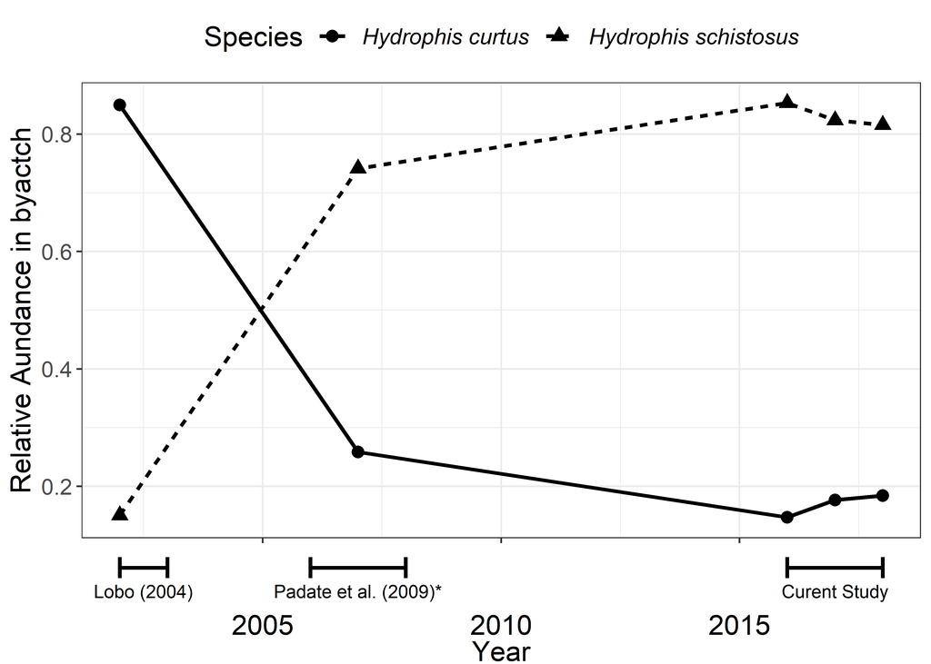

```r
#Plotting

assemblage <- CPUE.studies%>%
  group_by(Year)%>%
  mutate(Total = sum(Total.Abn))%>%
  group_by(Year, Species)%>%
  summarise(rel.prop = Total.Abn/Total)%>%
  ggplot(aes(Year, rel.prop))+
  geom_point(aes(shape = Species), size = 3)+
  geom_line(aes(linetype = Species, group = Species), size = 1)+
  labs(y = "Relative Aundance in byactch")+
  theme(axis.text.x = element_blank())+
  theme(legend.text = element_text(face = "italic"),
        axis.title.x = element_blank())

# adding study periods to plot

study_periods <- read.csv("./Data/Rao et al_data_study_periods.csv")

study_periods$study <- study_periods$ï..study

# rectangle plot
period1 <-  ggplot(study_periods)+
  geom_rect(aes(xmin = start.year, xmax = end.year, ymax = 1, ymin = -1,
                fill = study),  col = "black",
                 size = 0.1, height = 0.1)+
  geom_text(aes(x = median.year, y = 0, label = study), size = 3)+
  scale_fill_brewer(palette = "Greys", guide = F)+
  #scale_y_continuous(limits = c(0.5, 1.3))+
  labs(x = "Year")+
  theme_void()+
  theme(text = element_text(size = 15),
        axis.title.x = element_text(size = 15))

# arrow plot
period <-  ggplot(study_periods)+
  geom_errorbarh(aes(xmin = start.year, xmax = end.year, y = 1.75),
                 size = 1)+
  geom_text(aes(x = median.year, y = 0.75, label = study), size = 3.5)+
  scale_y_continuous(limits = c(0, 2.25))+
  labs(x = "Year")+
  theme_void()+
  theme(text = element_text(size =15),
        axis.title.x = element_text(size = 15),
        axis.text.x = element_text())

# final plot
ggpubr::ggarrange(assemblage, period,
                  ncol = 1,
                  heights = c(1, 0.2),
                  align = "v")
```

```r
ggsave("./Figures/figure 4.tiff", device = "tiff", last_plot(), dpi = "print",
       height = 4.5, width = 8)
```

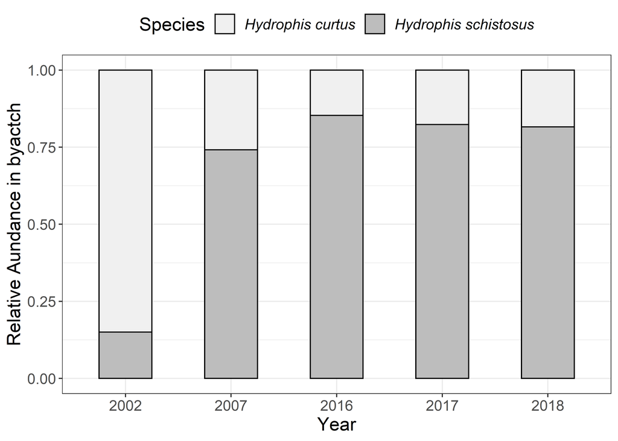

```r
# bar chart

CPUE.studies%>%
  mutate(Year = as.factor(Year))%>%
  group_by(Year)%>%
  mutate(Total = sum(Total.Abn))%>%
  group_by(Year, Species)%>%
  summarise(rel.prop = Total.Abn/Total)%>%
  ggplot(aes(Year, rel.prop))+
  geom_col(aes(fill = Species), col = "black", width = 0.5)+
  scale_fill_brewer(palette = "Greys")+
  labs(y = "Relative Aundance in byactch")+
  theme(legend.text = element_text(face = "italic"))
```

```r
ggsave("./Figures/figure 4b.tiff", device = "tiff", last_plot(), dpi = "print",
       height = 4.5, width = 8)
```

```r
#Z - test for proportion

CPUE.studies%>%
  group_by(Year)%>%
  mutate(N = sum(Total.Abn))%>%
  filter(Species == "Hydrophis curtus")%>%
  ungroup()%>%
  nest()%>%
  mutate(proptest = map(data, ~prop.test(.$Total.Abn, .$N)),
         sumry = map(proptest, broom::tidy),
         r = map2(proptest, data, ~proptest.r(.x, .y)))%>%
  select(sumry,r)%>%
  unnest()%>%
  select(estimate1:p.value, r)
```

| estimate1 | estimate2 | estimate3 | estimate4 | estimate5 | statistic | p.value | r |
| --- | --- | --- | --- | --- | --- | --- | --- |
| 0.8495575 | 0.2586207 | 0.1470588 | 0.1764706 | 0.1843318 | 281.6543 | 0 | 0.3995097 |

## 4.3 Difference in mortality of sea snakes in Trawlers across studies

```r
#summarising data from current study

mortality.studies <- snakes%>%
  filter(Gear.Type == "Trawler")%>%
  filter(Species == "Hydrophis curtus" |
           Species == "Hydrophis schistosus")%>% # keeping dominant species
  group_by(Year, Species)%>%
  summarise(n.alive = sum(Condition.at.encounter. == "Alive"),
            n.dead = sum(Condition.at.encounter. == "Dead"),
            mort.rate = (n.dead/(n.dead+n.alive)),
            Study = "Current")

# Attaching to previous study data

mortality.studies <- past_studies%>%
  select(Study, Year, Species, n.alive, n.dead, mort.rate)%>%
  bind_rows(mortality.studies)%>%
  mutate(N = n.alive + n.dead)%>%
  mutate(Study = factor(Study, levels = c("Lobo (2004)", "Padate et al. (2009)", "Current")))%>%
  group_by(Study, Species)%>%
  summarise(n.dead = sum(n.dead),
            N = sum(N),
            mort.rate = n.dead/N)

#table

knitr::kable(mortality.studies)
```

| Study | Species | n.dead | N | mort.rate |
| --- | --- | --- | --- | --- |
| Lobo (2004) | Hydrophis curtus | 132 | 192 | 0.6875000 |
| Lobo (2004) | Hydrophis schistosus | 4 | 34 | 0.1176471 |
| Padate et al. (2009) | Hydrophis curtus | 15 | NA | NA |
| Padate et al. (2009) | Hydrophis schistosus | 43 | NA | NA |
| Current | Hydrophis curtus | 51 | 75 | 0.6800000 |
| Current | Hydrophis schistosus | 110 | 346 | 0.3179191 |

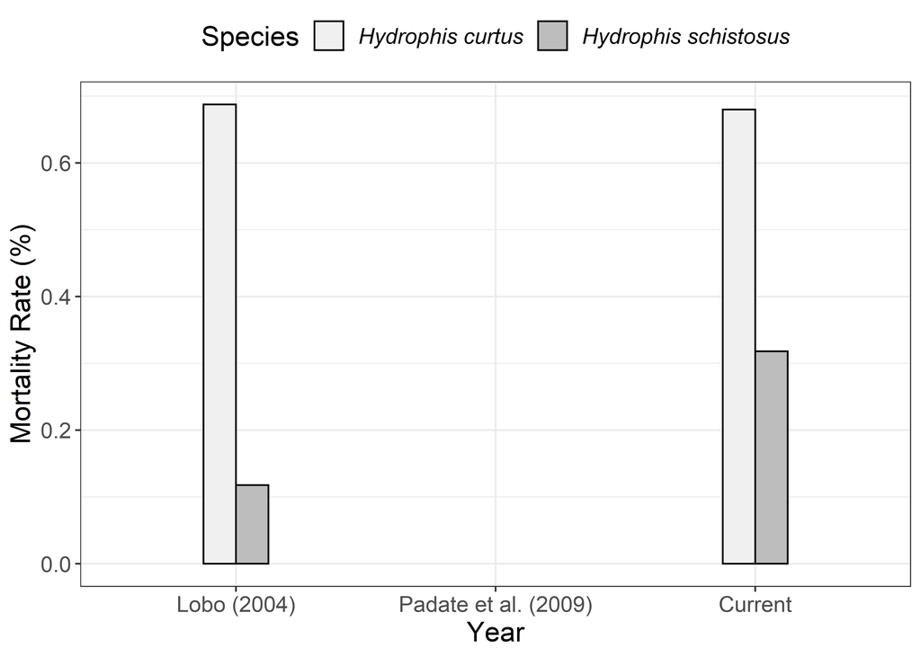

```r
#plot

mortality.studies%>%
  ggplot(aes(Study, mort.rate, fill = Species))+
  geom_col(position = position_dodge(preserve = "single"), col = "black", width = 0.25)+
  scale_fill_brewer(palette = "Greys")+
  labs(x = "Year", y = "Mortality Rate (%)")+
  theme(legend.text = element_text(face = "italic"))
```

```r
# test

mortality.studies%>%
  group_by(Species)%>%
  drop_na()%>%
  nest()%>%
  mutate(proptest = map(data, ~prop.test(.$n.dead, .$N)),
         #mod = map(data, ~lm(rel.prop ~ Year, data = .)),
         sumry = map(proptest, broom::tidy),
         r = map2(proptest, data, ~proptest.r(.x, .y)))%>%
  select(sumry,r)%>%
  unnest()%>%
  select(estimate1:p.value, r)
```

| Species | estimate1 | estimate2 | statistic | p.value | r |
| --- | --- | --- | --- | --- | --- |
| Hydrophis curtus | 0.6875000 | 0.6800000 | 0.000000 | 1.0000000 | 0.0000000 |
| Hydrophis schistosus | 0.1176471 | 0.3179191 | 4.997571 | 0.0253829 | 0.0131515 |

# 5 Increase in fishing pressure in Konkan 2000 - 2020

In order to understand the change in fishing pressure in the region we gathered data on the number of vessels of each craft type (mechanised, motorised and non- motorised) for Maharashtra and Goa from CMFRI Marine Fisheries Census for 2005 and 2010; Fisheries Department for 2014, 2015, 2017 and 2018; Jena and George (2018) for 2016 and the Handbook on Fisheries Statistics for 2019. The CMFRI Marine Fisheries Census recorded all vessels across multiple harbours across each state. The other sources reported on registered vessels only. Change in the number of vessels of each craft type from 2005 to 2019 were tested using log – linear regression. We compared the number of vessels of each craft across Maharashtra and goa using a t – test.

```r
#importing data on number of vessels

vessels <- read.csv("./Data/Rao et al_data_state-craft-gear.csv")

vessels$Year <- vessels$ï..Year
```

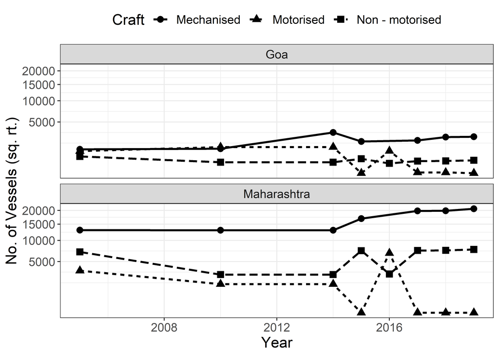

```r
#plot

vessels%>%
  ggplot(aes(Year, n, shape = Craft))+
  geom_point(size = 3)+
  geom_line(aes(group = Craft, linetype = Craft), size = 1)+
  scale_y_sqrt()+
  labs(y = "No. of Vessels (sq. rt.)")+
  facet_wrap(~ State, ncol = 1)
```

```r
ggsave("./Figures/figure 5.tiff", device = "tiff", last_plot(), dpi = "print",
       height = 6, width = 8)
```

```r
#testing change in number of vessels over years

vessels%>%
  group_by(State, Craft)%>%
  nest()%>%
  mutate(mod = map(data, ~glm(n ~ Year, data = ., family = poisson())),
         sumry = map(mod, broom::tidy),
         r2 = map(mod, ~mcfadden(.)))%>%
  select(sumry, r2)%>%
  unnest()%>%
  arrange(desc(r2))
```

| State | Craft | term | estimate | std.error | statistic | p.value | r2 |
| --- | --- | --- | --- | --- | --- | --- | --- |
| Maharashtra | Mechanised | (Intercept) | -69.9447237 | 1.3999812 | -49.961190 | 0 | 0.7467118 |
| Maharashtra | Mechanised | Year | 0.0395470 | 0.0006949 | 56.913780 | 0 | 0.7467118 |
| Goa | Mechanised | (Intercept) | -115.4983459 | 4.2006942 | -27.495062 | 0 | 0.5441047 |
| Goa | Mechanised | Year | 0.0611171 | 0.0020846 | 29.318823 | 0 | 0.5441047 |
| Goa | Non - motorised | (Intercept) | 86.2325473 | 8.6498363 | 9.969269 | 0 | 0.3073411 |
| Goa | Non - motorised | Year | -0.0399799 | 0.0042961 | -9.306161 | 0 | 0.3073411 |
| Goa | Motorised | (Intercept) | 252.8613557 | 5.8641018 | 43.120219 | 0 | 0.2632877 |
| Goa | Motorised | Year | -0.1224781 | 0.0029154 | -42.010095 | 0 | 0.2632877 |
| Maharashtra | Motorised | (Intercept) | 185.9700181 | 3.4680508 | 53.623788 | 0 | 0.1044864 |
| Maharashtra | Motorised | Year | -0.0886872 | 0.0017235 | -51.458983 | 0 | 0.1044864 |
| Maharashtra | Non - motorised | (Intercept) | -33.6241328 | 2.2838299 | -14.722696 | 0 | 0.0459403 |
| Maharashtra | Non - motorised | Year | 0.0209820 | 0.0011336 | 18.508824 | 0 | 0.0459403 |

```r
#testing difference in number of vessels between Mah and Goa

vessels%>%
  group_by(Craft)%>%
  nest()%>%
  mutate(mod = map(data, ~t.test(n ~ State, data = .)),
         sumry = map(mod, broom::tidy),
         d = map(data, ~lsr::cohensD(n ~ State, data = .)))%>%
  select(sumry, d)%>%
  unnest()%>%
  arrange(desc(d))%>%
  select(estimate:p.value, d)
```

| Craft | estimate | estimate1 | estimate2 | statistic | p.value | d |
| --- | --- | --- | --- | --- | --- | --- |
| Mechanised | -14568.29 | 2054.429 | 16622.714 | -10.598781 | 0.0000233 | 5.6652869 |
| Non - motorised | -5365.00 | 304.625 | 5669.625 | -6.387398 | 0.0003649 | 3.1936991 |
| Motorised | -1103.25 | 558.750 | 1662.000 | -1.260113 | 0.2435439 | 0.6300565 |

# 6 Study site map

```r
library(tmap)
library(osmdata)

study_sites <- read.csv("./data/Rao et al_data_study_site.csv")

# geocoding study sites

library(ggmap)

study_sites <- study_sites%>%
  filter(Study != "2006-2008")%>%
  mutate(Name = as.character(Name))%>%
  mutate_geocode(Name)

knitr::kable(study_sites)
```

| Study | Name | lon | lat |
| --- | --- | --- | --- |
| 2016 - 2018 | Malvan | 73.47105 | 16.06307 |
| 2002 - 2003 | Chapora | 73.74337 | 15.60212 |
| 2002 - 2003 | Vasco da Gama, Mormugao | 73.81657 | 15.38891 |
| 2002 - 2003 | Malim Jetty | 73.83445 | 15.50495 |
| 2002 - 2003 | Betul, Ambelim | 73.95637 | 15.14703 |
| 2016 - 2018 | Vengurla | 73.63890 | 15.85141 |

```r
# converting to simplfe feature

library(sf)

study_sites <- st_as_sf(study_sites, coords = c("lon", "lat"))

st_crs(study_sites) <- 4326

# getting study extent

study_ext <- st_bbox(study_sites)

# getting osm map

library(osmdata)

land_raw <- opq(bbox = study_ext, timeout = 100)%>%
  add_osm_feature(key = 'admin_level', value = '4')%>%
  osmdata_sf()%>%
  unique_osmdata()

land <- land_raw$osm_multipolygons

st_crs(land) <- 4326

india <- read_sf("./Data/India-States.shp")

# plotting site map

ss_main <- tm_shape(land)+
  tm_polygons()+
  tm_text("name", remove.overlap = F)+
  tm_shape(india)+
  tm_polygons()+
tm_shape(study_sites, bbox = study_ext+c(-0.5,-.5,0.5,0.5), is.master = T)+
  tm_symbols(size = 1, shape = "Study", border.lwd = 2.5, border.col = "black", col = "gray")+
  tm_text("Name", size = 0.7,fontface = "bold",
          ymod = -0.7, xmod = -0.75, remove.overlap = T)+
  tm_graticules(n.x = 5)+
  tm_scale_bar(position = c("left", "top"), text.size = 0.5) +
  tm_compass(position = c('right', 'top'), size = 5)+
  tm_style(style = "gray")+
  tm_layout(scale = 1.5, legend.position = c("left", "bottom"))

# making inset map

ext <- st_as_sfc(study_ext+c(-1.2,-1.2,1.2,1.2))

ss_inset <- tm_shape(india)+
  tm_polygons()+
tm_shape(ext)+
  tm_borders(lwd = 3)+
  tm_style("gray")+
  tm_layout(scale = 1.5)

# making final map

vp <- grid::viewport(x = 0.75, y = 0.15, width = 0.2, height = 0.3)

tmap_save(ss_main, insets_tm = ss_inset, insets_vp = vp,
          "./Figures/Figure_1.tiff", height = 8, width = 8)
```